# Experiment 2b

# Outline

In the following script we will analyze the data from [Luque et al. (2020)](https://psyarxiv.com/xnmfc/). The raw data are available [here](https://osf.io/9x3tm/) and described [here](https://osf.io/s8mey/).

The analysis will consist in the fitting of the reaction times of the devalued trials of experiment 2b using the [Fast-DM](https://www.psychologie.uni-heidelberg.de/ae/meth/fast-dm/index-en.html) implementation of Ratcliff’s Diffusion Model [(described here)](https://link.springer.com/article/10.3758/BF03192967).

The general strategy was the the following:

- First, data of the devalued phases of the design were extracted from the raw data files. As in Luque et al. (2020), the trials without a response or with a response were removed, as well as the consumption trials.
- The remaining valid trials were dividided in three groups. The first contained the non-devalued trials, the second contained the devalued O<sup>10</sup> trials and the third the devalued O<sup>100</sup> trials.
- The first group of trials (range of valid trials: 31 to 48, mean 42.15) were fitted using Fast-DM (maximum likelihood method), with three free parameters, a, v and t0. The objective of this first adjustment was to extract the values of t0 to use them in further steps.
- The second (range of valid trials: 10 to 24, mean 20.22) and third (range of valid trials: 10 to 24, mean 20.32) groups were then adjusted using the t0 parameter obtained in the previous step (free parameters a and v only, range of valid trials per group: 10 to 24).

#### Extract the data from the files and fit the model

```r
#source('./scripts/generate_fast_dm.R')
```

#### Analysis

Load auxiliary functions

```r
source('./scripts/functions/fast_dm_functions.R')
```

Load the data obtained from fitting the models

```r
results <- map_df(list.files('output/exp2b/fast_dm/logs/', '(1|3)_[0-9]', full.names = TRUE),
                  load_participant_D)
```

Generate summary plot of the parameters for each condition and group

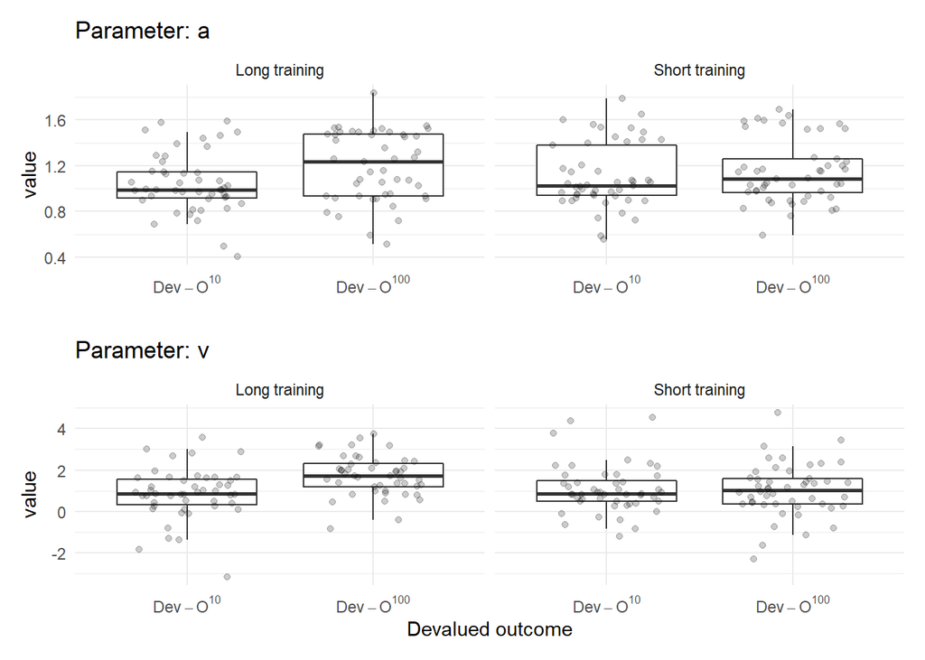

```r
list_to_patch <- map(c("a", "v"), plot_list, results = results)
list_to_patch[[1]] / list_to_patch[[2]] + theme(legend.position = "none") + xlab("Devalued outcome")
```

Omnibus mixed ANOVA (Group x Condition x Parameter)

```r
main_omnibus <- afex::aov_ez("id", "value",
                             results %>%
                               mutate(id = paste0(group,"_",id)),
                             between = "group", within = c("condition","parameter"))
```

```
## Converting to factor: group
```

```
## Contrasts set to contr.sum for the following variables: group
```

```r
papaja::apa_table(papaja::apa_print.afex_aov(main_omnibus)$table, caption = "Omnibus ANOVA")
```

(#tab:unnamed-chunk-5)

*Omnibus ANOVA*

| Effect | $F$ | $\mathit{df}_1^{GG}$ | $\mathit{df}_2^{GG}$ | $\mathit{MSE}$ | $p$ | $\hat{\eta}^2_G$ |
| --- | --- | --- | --- | --- | --- | --- |
| Group | 1.06 | 1 | 93 | 1.27 | .306 | .005 |
| Condition | 12.61 | 1 | 93 | 0.50 | .001 | .023 |
| Parameter | 0.25 | 1 | 93 | 0.82 | .618 | .001 |
| Group $\times$ Condition | 12.90 | 1 | 93 | 0.50 | .001 | .024 |
| Group $\times$ Parameter | 1.87 | 1 | 93 | 0.82 | .175 | .006 |
| Condition $\times$ Parameter | 9.53 | 1 | 93 | 0.27 | .003 | .010 |
| Group $\times$ Condition $\times$ Parameter | 15.03 | 1 | 93 | 0.27 | < .001 | .015 |

T-tests for each group and parameter comparing the conditions

```r
to_print = ""
for (cur_test in list(list(cur_group = "1", cur_parameter = "a", cur_name = "Short training"),
                      list(cur_group = "1", cur_parameter = "v", cur_name = "Short training"),
                      list(cur_group = "3", cur_parameter = "a", cur_name = "Long training"),
                      list(cur_group = "3", cur_parameter = "v", cur_name = "Long training"))){

  cur_result <- custom_paired_t.test(cur_test, results)
  to_print <- paste0(to_print,
                     paste("Group:", cur_test$cur_name,
                           " - Parameter:", cur_test$cur_parameter, "\n\n"),
                     papaja::apa_print(cur_result)["full_result"],"\n\n")
}
```

Group: Short training - Parameter: a

$M_d = -0.04$, 95% CI $[-0.15$, $0.07]$, $t(47) = -0.72$, $p = .477$

Group: Short training - Parameter: v

$M_d = 0.05$, 95% CI $[-0.31$, $0.40]$, $t(47) = 0.26$, $p = .799$

Group: Long training - Parameter: a

$M_d = -0.15$, 95% CI $[-0.27$, $-0.03]$, $t(46) = -2.48$, $p = .017$

Group: Long training - Parameter: v

$M_d = -0.89$, 95% CI $[-1.23$, $-0.56]$, $t(46) = -5.37$, $p < .001$